# Assessment of Impact of COVID19

Frank NAMUGERA

2021-04-20

### Details of the Tourism Establishments

Table 1: Respondents by Type of Business

| 2. Type of Business | Count | Per |
| --- | --- | --- |
| Airlines | 11 | 1% |
| Art and Craft Enterprise | 131 | 12% |
| Food Companies (Café Javas) | 7 | 1% |
| Government agency | 2 | 0% |
| Hotel and Accommodation | 833 | 78% |
| Others (Specify) | 3 | 0% |
| Travel Business/Tour Operator | 79 | 7% |
| Total | 1066 | - |

Table 2: Demographics of the Respondents

| Respondent | Count | Per |
| --- | --- | --- |
| Accountant | 136 | 13% |
| CEO | 80 | 8% |
| Director/Manager | 356 | 33% |
| Front Office Manager | 164 | 15% |
| Office Assistant | 50 | 5% |
| Other (Specify) | 67 | 6% |
| Receptionist | 152 | 14% |
| Sales Officer | 61 | 6% |
| Total | 1066 | - |

Table 3: Years in Business

| 4. Years in Business of the Company | Count | Per |
| --- | --- | --- |
| 0-3years | 107 | 10% |
| 4-6 years | 231 | 22% |
| 7-9 years | 272 | 26% |
| 10-12 years | 264 | 25% |
| 13-15 years | 97 | 9% |
| 15+ years | 95 | 9% |
| Total | 1066 | - |

Table 4: Years in Business and Business Type

| 4. Years in Business of the Company | Airlines | Art and Craft Enterprise | Food Companies (Café Javas) | Hotel and Accommodation | Others (Specify) | Travel Business/Tour Operator | Government agency | Total |
| --- | --- | --- | --- | --- | --- | --- | --- | --- |
| 0-3years | 1 | 29 | 2 | 58 | 1 | 16 | NA | 107 |
| 4-6 years | 2 | 48 | 1 | 167 | NA | 13 | NA | 231 |
| 7-9 years | NA | 20 | 2 | 230 | NA | 19 | 1 | 272 |
| 10-12 years | NA | 21 | 2 | 222 | 1 | 17 | 1 | 264 |
| 13-15 years | 1 | 9 | NA | 79 | NA | 8 | NA | 97 |
| 15+ years | 7 | 4 | NA | 77 | 1 | 6 | NA | 95 |
| Total | 11 | 131 | 7 | 833 | 3 | 79 | 2 | 1066 |

Table 5: Employees by Establishment

| 5. Approximately how many employees are there in your organization? | Count | Per |
| --- | --- | --- |
| 0-10 employees | 485 | 45% |
| 11-20 employees | 238 | 22% |
| 21-30 employees | 192 | 18% |
| 31-40 employees | 61 | 6% |
| 41-50 employees | 24 | 2% |
| Over 50 employees | 43 | 4% |
| Over 100 employees | 23 | 2% |
| Total | 1066 | - |

Table 6: Employees by Years in Business of a company

| Numer_of_Employees | 0-3years | 4-6 years | 7-9 years | 10-12 years | 13-15 years | 15+ years | Total |
| --- | --- | --- | --- | --- | --- | --- | --- |
| 0-10 employees | 70 | 123 | 110 | 114 | 39 | 29 | 485 |
| 11-20 employees | 14 | 43 | 82 | 60 | 23 | 16 | 238 |
| 21-30 employees | 11 | 46 | 51 | 52 | 17 | 15 | 192 |
| 31-40 employees | 4 | 8 | 17 | 16 | 5 | 11 | 61 |
| 41-50 employees | 2 | 3 | 5 | 6 | 6 | 2 | 24 |
| Over 50 employees | 4 | 5 | 3 | 10 | 6 | 15 | 43 |
| Over 100 employees | 2 | 3 | 4 | 6 | 1 | 7 | 23 |
| Total | 107 | 231 | 272 | 264 | 97 | 95 | 1066 |

Table 7: Employees by Business Type

| Numer_of_Employees | Airlines | Art and Craft Enterprise | Hotel and Accommodation | Others (Specify) | Travel Business/Tour Operator | Food Companies (Café Javas) | Government agency | Total |
| --- | --- | --- | --- | --- | --- | --- | --- | --- |
| 0-10 employees | 1 | 130 | 291 | 3 | 60 | NA | NA | 485 |
| 11-20 employees | NA | 1 | 219 | NA | 15 | 3 | NA | 238 |
| 21-30 employees | 1 | NA | 190 | NA | 1 | NA | NA | 192 |
| 31-40 employees | 2 | NA | 58 | NA | 1 | NA | NA | 61 |
| 41-50 employees | NA | NA | 23 | NA | NA | NA | 1 | 24 |
| Over 50 employees | 5 | NA | 33 | NA | 2 | 3 | NA | 43 |
| Over 100 employees | 2 | NA | 19 | NA | NA | 1 | 1 | 23 |
| Total | 11 | 131 | 833 | 3 | 79 | 7 | 2 | 1066 |

Table 8: Services offered by Tourism Businesses

| Service | Count | Per |
| --- | --- | --- |
| Booking/Ticketing services | 85 | 5% |
| Food and Accommodation | 839 | 54% |
| Other | 269 | 17% |
| Recreational services | 217 | 14% |
| Tour Guiding services | 90 | 6% |
| Transport Services | 64 | 4% |
| Total | 1564 | - |

Business Performance  
Table 9: Business Performance

| 7. How do you rate your business performance in the last 12 months? | Count | Per |
| --- | --- | --- |
| Poor | 792 | 74% |
| Fair | 264 | 25% |
| Good | 10 | 1% |
| Total | 1066 | - |

Table 10: Business Performance

| 2. Type of Business | Poor | Fair | Good |
| --- | --- | --- | --- |
| Airlines | 11 | NA | NA |
| Art and Craft Enterprise | 105 | 26 | NA |
| Food Companies (Café Javas) | 2 | 5 | NA |
| Government agency | 1 | 1 | NA |
| Hotel and Accommodation | 607 | 216 | 10 |
| Others (Specify) | 1 | 2 | NA |
| Travel Business/Tour Operator | 65 | 14 | NA |

Table 11: Years in Business and Business Performance

| 4. Years in Business of the Company | Poor | Fair | Good |
| --- | --- | --- | --- |
| 0-3years | 78 | 29 | NA |
| 4-6 years | 169 | 60 | 2 |
| 7-9 years | 179 | 88 | 5 |
| 10-12 years | 206 | 56 | 2 |
| 13-15 years | 77 | 19 | 1 |
| 15+ years | 83 | 12 | NA |

Employment  
Table 12: Workdforce status

| variable | value |
| --- | --- |
| 17a. What was your total number of workers before COVID-19? | 31276 |
| 17b. What was is your current total number of workers | 17883 |
| 17c. How many of your workers have were laid off due to the pandemic? | 6536 |
| 17d. How many of your workers are facing unpaid leave due to the pandemic? | 6860 |
| 17e. How many of your workers are facing pay cut due to the pandemic? | 11854 |

Table 13: Status of Workforce by Tourism Industry

| 2. Type of Business | 17a. What was your total number of workers before COVID-19? | 17b. What was is your current total number of workers | 17c. How many of your workers have were laid off due to the pandemic? | 17d. How many of your workers are facing unpaid leave due to the pandemic? | 17e. How many of your workers are facing pay cut due to the pandemic? | Total |
| --- | --- | --- | --- | --- | --- | --- |
| Airlines | 1060 | 813 | 14 | 233 | 300 | 2420 |
| Art and Craft Enterprise | 341 | 148 | 124 | 68 | 102 | 783 |
| Food Companies (Café Javas) | 508 | 275 | 70 | 163 | 184 | 1200 |
| Government agency | 2500 | 2500 | 0 | 0 | 0 | 5000 |
| Hotel and Accommodation | 25897 | 13644 | 6056 | 6199 | 10855 | 62651 |
| Others (Specify) | 13 | 8 | 5 | 0 | 3 | 29 |
| Travel Business/Tour Operator | 957 | 495 | 267 | 197 | 410 | 2326 |
| Total | 31276 | 17883 | 6536 | 6860 | 11854 | 74409 |

Table 14: Workdforce status by Hotel

| 1. What is the Company/Organisation/Business name? | 17a. What was your total number of workers before COVID-19? | 17b. What was is your current total number of workers | 17c. How many of your workers have were laid off due to the pandemic? | 17d. How many of your workers are facing unpaid leave due to the pandemic? | 17e. How many of your workers are facing pay cut due to the pandemic? | Total |
| --- | --- | --- | --- | --- | --- | --- |
| 2 friends beach hotel Entebbe | 15 | 7 | 8 | 0 | 7 | 37 |
| 2 friends Beach Hotel Entebbe | 32 | 16 | 5 | 11 | 0 | 64 |
| 24/7 Hotel buikwe | 21 | 15 | 0 | 6 | 15 | 57 |
| 24/7 Worldwide Travel and Tours Ltd | 3 | 3 | 0 | 0 | 3 | 9 |
| 3K Palace motel Mpigi | 8 | 3 | 0 | 5 | 0 | 16 |
| 7 seasons Hotel Entebbe | 35 | 20 | 15 | 0 | 20 | 90 |
| Acacia Hotel Mbarara | 15 | 11 | 3 | 1 | 2 | 32 |
| Acactus hotel Kampala | 14 | 14 | 0 | 0 | 14 | 42 |
| Accra Guesthouse Kampala | 9 | 3 | 6 | 0 | 3 | 21 |
| Achilles Motel Kagadi | 12 | 3 | 9 | 0 | 3 | 27 |
| Acholi Inn Gulu | 55 | 27 | 0 | 28 | 27 | 137 |
| ACIF Hotel Kasese | 16 | 9 | 7 | 0 | 9 | 41 |
| Activentures safaris Ltd | 10 | 4 | 0 | 6 | 4 | 24 |
| Admiral hotel Kampala | 30 | 20 | 10 | 0 | 20 | 80 |
| Adnec motel Kagadi | 20 | 13 | 0 | 7 | 13 | 53 |
| Adonai guesthouse Kyenjojo | 10 | 7 | 3 | 0 | 7 | 27 |
| Africa’s Great Exploration | 8 | 3 | 0 | 5 | 3 | 19 |
| African Pearl Safaris | 8 | 5 | 0 | 3 | 5 | 21 |
| African Tribe Hotel Kampala | 28 | 20 | 0 | 8 | 13 | 69 |
| African village hotel mukono | 33 | 20 | 0 | 13 | 5 | 71 |
| Afrika Tour | 16 | 4 | 10 | 2 | 4 | 36 |
| Afrique suites hotel Kampala | 20 | 14 | 0 | 6 | 10 | 50 |
| Afro Smile Hotel Jinja | 16 | 12 | 4 | 0 | 12 | 44 |
| Agenda 2000 hotels Ltd | 22 | 8 | 0 | 14 | 8 | 52 |
| AGIP motel mbarara | 36 | 21 | 15 | 0 | 21 | 93 |
| Air View Guesthouse Mbale | 4 | 1 | 3 | 0 | 1 | 9 |
| Airport View hotel ,Entebbe | 26 | 14 | 4 | 8 | 14 | 66 |
| AK Complex Hotel Kasese | 32 | 20 | 12 | 0 | 20 | 84 |
| AK new generation guesthouse fort portal | 7 | 4 | 3 | 0 | 4 | 18 |
| Akello Hotel Soroti | 44 | 33 | 8 | 3 | 33 | 121 |

[output cut: 1029 more lines]

Table 15: Status of current Workforce

| 18. Have you downsized/ increased your work force in the last 12 months? | Count | Per | Mean |
| --- | --- | --- | --- |
| Downsized | 946 | 89% | 50% |
| Increased | 2 | 0% | 84% |
| No Change | 118 | 11% | NA |
| Total | 1066 | - | NA |

Table 16: Status of current Workforce by Tourism Industry:

| 2. Type of Business | Downsized | Increased | No Change | Total |
| --- | --- | --- | --- | --- |
| Airlines | 10 | NA | 1 | 11 |
| Art and Craft Enterprise | 80 | 1 | 50 | 131 |
| Food Companies (Café Javas) | 7 | NA | NA | 7 |
| Hotel and Accommodation | 779 | NA | 54 | 833 |
| Others (Specify) | 2 | NA | 1 | 3 |
| Travel Business/Tour Operator | 68 | 1 | 10 | 79 |
| Government agency | NA | NA | 2 | 2 |
| Total | 946 | 2 | 118 | 1066 |

Occupancy Levels and Room Cancellations in 2021  
Table 17: Mean Percentage Occupancy levels

| Month | Mean_occupancy |
| --- | --- |
| Jan | 24 |
| Feb | 27 |
| Mar | 31 |
| Average | 27 |

Table 18: Occupancy levels by Hotel

| Business_name | 20a. What was your Occupancy level for Jan 2021 | 20b. What was your Occupancy level for Feb 2021 | 20c. What was your Occupancy level for Mar 2021 | Average |
| --- | --- | --- | --- | --- |
| Speke Resort Munyonyo | 30 | 38 | 45 | 38 |
| Kolping Hotel Kampala | 20 | 25 | 25 | 23 |
| Nanjing Restaurant and Motel | 17 | 23 | 38 | 26 |
| Belline Hotel Bushenyi | 28 | 28 | 0 | 19 |
| Eureka Motel Bushenyi | 19 | 20 | 25 | 21 |
| Bettinna Resort Hotel Bushenyi | 30 | 24 | 24 | 26 |
| Y-Save Safaris | NA | NA | NA | NaN |
| Imperial Resort Entebbe | 24 | 28 | 32 | 28 |
| Executive Airport Hotel | 10 | 15 | 24 | 16 |
| Victoria Royal beach Hotel | 20 | 15 | 45 | 27 |
| Tembo Art and Craft Main Shop | NA | NA | NA | NaN |
| Entebbe Travellers Inn | 32 | 76 | 40 | 49 |
| Tembo Craft Village 7 | NA | NA | NA | NaN |
| Juakali Craft Centre Shop 2 | NA | NA | NA | NaN |
| Baskon Hotel Entebbe | 17 | 13 | 17 | 16 |
| Lake Victotia Hotel Entebbe | 25 | 40 | 50 | 38 |
| Sky Hotel Kampala | 34 | 32 | 40 | 35 |
| Frontiers Hotel | 17 | 22 | 28 | 22 |
| Sunset Hotel Kampala | 60 | 66 | 60 | 62 |
| Grand Global Hotel Kikoni Kampala | 32 | 32 | 30 | 31 |
| SERENA HOTEL KIGO | 30 | 35 | 30 | 32 |
| Santa Maria Hotel | 11 | 32 | 17 | 20 |
| Sheron Hotel Kampala | 20 | 20 | 30 | 23 |
| 7 seasons Hotel Entebbe | 15 | 10 | 22 | 16 |
| Jorin Hotel Kampala | 17 | 11 | 14 | 14 |
| Protea Hotel Marriot Entebbe | 36 | 42 | 41 | 40 |
| Palms Beach Hotel and restaurant | 20 | 20 | 30 | 23 |
| Pulickal Airport Hotel | 17 | 20 | 22 | 20 |
| My guesthouse | 20 | 20 | 33 | 24 |
| Rosen villas hotel kampala | 25 | 25 | 30 | 27 |

[output cut: 1042 more lines]

Table 19: Room Cancellations and losses

| Business_name | 24a. How many room cancellations have you had in the last one year | 24b. How much have you lost in revenues due to room cancellations in Uganda Shillings in the last one year |
| --- | --- | --- |
| Speke Resort Munyonyo | 1500 | 800000000 |
| Kolping Hotel Kampala | 12 | 12000000 |
| Nanjing Restaurant and Motel | 100 | 200000000 |
| Belline Hotel Bushenyi | 0 | 0 |
| Eureka Motel Bushenyi | 0 | 0 |
| Bettinna Resort Hotel Bushenyi | 4 | 9600000 |
| Imperial Resort Entebbe | 22 | 230000000 |
| Executive Airport Hotel | 2 | 5400000 |
| Victoria Royal beach Hotel | 8 | 4000000 |
| Entebbe Travellers Inn | 4 | 4800000 |
| Lake Victotia Hotel Entebbe | 250 | 500000000 |
| Sky Hotel Kampala | 25 | 25000000 |
| Frontiers Hotel | 0 | 0 |
| Sunset Hotel Kampala | 0 | 0 |
| Grand Global Hotel Kikoni Kampala | 120 | 90000000 |
| SERENA HOTEL KIGO | 500 | 600000000 |
| Santa Maria Hotel | 2 | 18900000 |
| Sheron Hotel Kampala | 0 | 0 |
| 7 seasons Hotel Entebbe | 0 | 0 |
| Jorin Hotel Kampala | 0 | 0 |
| Protea Hotel Marriot Entebbe | 1000 | 800000000 |
| Palms Beach Hotel and restaurant | 12 | 84000000 |
| Pulickal Airport Hotel | 27 | 140000000 |
| Haven hotel kampala | 6 | 5000000 |
| Munyonyo springs gardens | 6 | 6000000 |
| Wilsen hotel Kampala | 0 | 0 |
| Gogret motel | 0 | 0 |
| Forest Cottages Kampala | 215 | 600000000 |
| La Grande Hotel Kampala | 60 | 250000000 |
| Hilton gardens in Kampala | 85 | 500000000 |

[output cut: 447 more lines]

Table 19: Room Cancellations and losses by business type:

| Business_type | 24a. How many room cancellations have you had in the last one year | 24b. How much have you lost in revenues due to room cancellations in Uganda Shillings in the last one year |
| --- | --- | --- |
| Hotel and Accommodation | 40 | 63173925 |
| Average | 40 | 63173925 |

Table 19: Room Cancellations and losses by business age:

| Business_years | 24a. How many room cancellations have you had in the last one year | 24b. How much have you lost in revenues due to room cancellations in Uganda Shillings in the last one year |
| --- | --- | --- |
| 0-3years | 10 | 30050000 |
| 4-6 years | 49 | 63368293 |
| 7-9 years | 30 | 41968687 |
| 10-12 years | 36 | 56401018 |
| 13-15 years | 38 | 74876786 |
| 15+ years | 68 | 116033582 |
| Average | 40 | 63173925 |

Booking Patterns  
Table 20: Number of Bookings by tourist type

```
# A tibble: 2 x 5
# Groups:   Tourist [2]
  Tourist           `Jul-Aug 2020` `Sep-Oct 2020` `Nov-Dec 2020` `Jan-Mar 2021`
  <chr>                      <dbl>          <dbl>          <dbl>          <dbl>
1 Domestic tourists          21914          30404          44219          62268
2 Foreign tourists            5628           9776          18073          21196
```

Table 21: Number of Bookings by Business Type:

```
# A tibble: 3 x 5
# Groups:   2. Type of Business [3]
  `2. Type of Busin~ `Jul-Aug 2020` `Sep-Oct 2020` `Nov-Dec 2020` `Jan-Mar 2021`
  <chr>                       <dbl>          <dbl>          <dbl>          <dbl>
1 Airlines                       96           2442           3460           4146
2 Hotel and Accommo~          52818          71886         102702         140469
3 Travel Business/T~           2154           5852          18378          22286
```

Table 22: Number of Foreign Bookings by Business Type

```
# A tibble: 3 x 5
# Groups:   2. Type of Business [3]
  `2. Type of Busin~ `Jul-Aug 2020` `Sep-Oct 2020` `Nov-Dec 2020` `Jan-Mar 2021`
  <chr>                       <dbl>          <dbl>          <dbl>          <dbl>
1 Airlines                       45            795           1235           1396
2 Hotel and Accommo~           4765           6954          11082          13871
3 Travel Business/T~            818           2027           5756           5929
```

Table 23: Number of Domestic Bookings by Business Type

```
# A tibble: 3 x 5
# Groups:   2. Type of Business [3]
  `2. Type of Busin~ `Jul-Aug 2020` `Sep-Oct 2020` `Nov-Dec 2020` `Jan-Mar 2021`
  <chr>                       <dbl>          <dbl>          <dbl>          <dbl>
1 Airlines                        3            426            495            677
2 Hotel and Accommo~          21652          29079          40291          56377
3 Travel Business/T~            259            899           3433           5214
```

Table 24: Average Bookings by Business type

```
# A tibble: 3 x 5
# Groups:   2. Type of Business [3]
  `2. Type of Busin~ `Jul-Aug 2020` `Sep-Oct 2020` `Nov-Dec 2020` `Jan-Mar 2021`
  <chr>                       <dbl>          <dbl>          <dbl>          <dbl>
1 Airlines                        3             74            105            126
2 Hotel and Accommo~             21             29             41             56
3 Travel Business/T~              9             25             78             94
```

Table 25: Experiencing Cancellations of Bookings: **This section had NAs that i filtered out. Thats why the total is less than the number of surveys conducted**

| 11. Have you had any cancellations of bookings in the last 12 months? | Count | Per |
| --- | --- | --- |
| No | 309 | 33% |
| Yes | 614 | 67% |
| Total | 923 | - |

Table 26: Number and average cancellations and Loss in revenues by business type  
Averages:

| Business_type | 12. How many bookings have been cancelled in the last 12 months? | 13. How much is the estimated loss due to cancellations in terms of revenues in the last 12 months? Please provide response UGShs |
| --- | --- | --- |
| Airlines | 258 | 382700000 |
| Hotel and Accommodation | 119 | 107665688 |
| Travel Business/Tour Operator | 124 | 134894926 |
| Average | 122 | 115830365 |

Totals/Summations

[output not shown]

Table 27: Reasons for Cancellation of Bookings

| Reason | Count | per |
| --- | --- | --- |
| Hesitancy to travel | 440 | 27% |
| Lockdown that being imposed | 516 | 32% |
| No money for travel | 108 | 7% |
| Travel restrictions | 570 | 35% |

Other reasons:

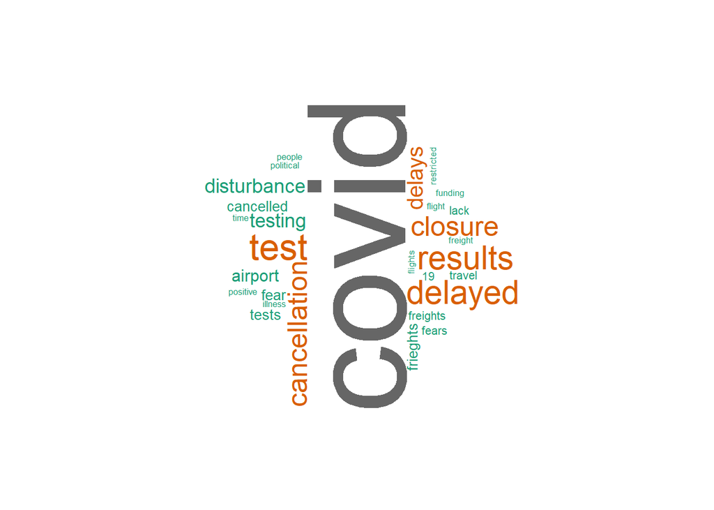

MICE-Meetings, Incentives, Conferences and Events  
Table 28: Volumes of Conferences held in the last one year. There are some outlier in this data set. These need to be question.

| Company | Conferences_held | Average_attendance | Estimate |
| --- | --- | --- | --- |
| 2 friends Beach Hotel Entebbe | 5 | 12 | 60 |
| Acacia Hotel Mbarara | 16 | 60 | 960 |
| Acholi Inn Gulu | 6 | 45 | 270 |
| Afro Smile Hotel Jinja | 5 | 18 | 90 |
| AGIP motel mbarara | 2 | 15 | 30 |
| Airport View hotel ,Entebbe | 6 | 25 | 150 |
| AK Complex Hotel Kasese | 16 | 60 | 960 |
| Akello Hotel Soroti | 2 | 60 | 120 |
| Al Nisaa Hotel and Spa | 10 | 20 | 200 |
| Alison and Dave’s Guesthouse | 2 | 23 | 46 |
| Amazon Guest House Kasese | 2 | 16 | 32 |
| Anderita beach hotel Entebbe | 0 | 0 | 0 |
| Areba Hotel Entebbe | 4 | 12 | 48 |
| Arise Africa international Christian Guesthouse | 13 | 15 | 195 |
| Asamar County Resort Mbarara | 8 | 40 | 320 |
| Asizar Crane Hotel Hoima | 5 | 20 | 100 |
| Beja Hotel Masindi | 6 | 18 | 108 |
| Believue Hotel Jinja | 10 | 20 | 200 |
| Best Western Plus The Athena Hotel | 20 | 25 | 500 |
| Bettinna Resort Hotel Bushenyi | 4 | 28 | 112 |
| Bilkon Hotel Jinja | 180 | 30 | 5400 |
| Bismillah Hotel Kabarole | 60 | 25 | 1500 |
| Bona Safari Villa Entebbe | 11 | 15 | 165 |
| Boomah Hotel Gulu | 113 | 75 | 8475 |
| Brisk Recreational Hotel Jinja | 15 | 55 | 825 |
| Buziga country resort | 11 | 60 | 660 |
| Camp David Inn Fort Portal | 3 | 40 | 120 |
| Canaan Hotel Golden Tulip Kampala | 60 | 30 | 1800 |
| Carpe Diem Entebbe | 4 | 18 | 72 |
| Christaine GuestHouse and Restaurant FortPortal | 5 | 12 | 60 |

[output cut: 270 more lines]

Outliers: The data need to be cleaned for these since they appear to be out of the norm.

| Company | Conferences_held | Average_attendance | Estimate |
| --- | --- | --- | --- |
| Hotel Triangle Mbarara | 60 | 250 | 15000 |
| Source Of the Nile Hotel Jinja | 300 | 200 | 60000 |
| Pope Paul Hotel Kampala | 500 | 100 | 50000 |
| Lake View Hotel Mbarara | 350 | 80 | 28000 |
| Kampala Serena Hotel | 250 | 60 | 15000 |
| Speke Resort Munyonyo | 1200 | 50 | 60000 |
| Silver Springs Hotel Kampala | 1300 | 50 | 65000 |
| Sherston Hotel Kampala | 720 | 50 | 36000 |
| Skyz Hotel Marriot | 900 | 25 | 22500 |

Using averages: (I have removed the outliers above)

| variable | Average |
| --- | --- |
| Conferences_held | 46.53512 |
| Average_attendance | 33.10702 |

Table 29: Hosting of Conferences:

| Response | count | Percent (%) |
| --- | --- | --- |
| No | 533 | 64% |
| Yes | 300 | 36% |
| Total | 833 | - |

Incomes in 2020  
Table 30: Receipt of change in income. The average is influenced by outliers. I have therefore dropped any record below 10000. This only drops one record.

| Response | Count | Average_change | percent(%) |
| --- | --- | --- | --- |
| Decline | 139 | 67025135 | 100% |

| 2. Type of Business | Response | Count | Average_change | percent(%) |
| --- | --- | --- | --- | --- |
| Art and Craft Enterprise | Decline | 131 | 55545753 | 94% |
| Food Companies (Café Javas) | Decline | 7 | 262857143 | 5% |
| Government agency | Decline | 1 | 200000000 | 1% |

Outlier record from the previous table:

| 1. What is the Company/Organisation/Business name? | 2. Type of Business | 15. Have you had a decline or increase in your sales in the last 12 months compared to before? | 16. If your answer is increase or declines, How much is the estimated loss/increase you have got for the last one year in Uganda Shillings due to COVID-19 |
| --- | --- | --- | --- |
| Uganda Wildlife Authority | Government agency | Decline | 99 |

Table 31: Lost income in the last one year

| Response | Count | per |
| --- | --- | --- |
| 100% of income lost | 121 | 11% |
| Less than 25% of income lost | 0 | 0% |
| Less than 50% of income lost | 7 | 1% |
| No income lost | 0 | 0% |
| Over 50% of income lost | 941 | 88% |

Business prospects for 2021 and Stimulus Package required  
Table 32: View of the Business Prospects for 2021

| Business_prospects | count | percent(%) |
| --- | --- | --- |
| Worse | 90 | 8% |
| Bad | 291 | 27% |
| Fair | 517 | 48% |
| Good | 160 | 15% |
| Very Good | 8 | 1% |
| Total | 1066 | - |

Table 33: View of the Business Prospects for 2021 by Business Type

| Type of Business | Worse | Bad | Fair | Good | Very Good | Total |
| --- | --- | --- | --- | --- | --- | --- |
| Art and Craft Enterprise | 33 | 47 | 45 | 6 |  | 131 |
| Hotel and Accommodation | 54 | 220 | 427 | 125 | 7 | 833 |
| Travel Business/Tour Operator | 3 | 23 | 35 | 17 | 1 | 79 |
| Government agency |  | 1 | 1 |  |  | 2 |
| Airlines |  |  | 4 | 7 |  | 11 |
| Food Companies (Café Javas) |  |  | 3 | 4 |  | 7 |
| Others (Specify) |  |  | 2 | 1 |  | 3 |
| Total | 90 | 291 | 517 | 160 | 8 | 1066 |

| Stimulus_package | Count | per |
| --- | --- | --- |
| Commercial debt repayment support | 211 | 7% |
| Expert advice on business strategy and recovery | 262 | 8% |
| Financial support for cash flow and recovery | 661 | 21% |
| Intensify marketing and promotion of Domestic Tourism to support Tourism business | 559 | 18% |
| Provide lower interest rates | 425 | 14% |
| Tax reductions or deferments | 824 | 27% |
| Virtual training for upskilling entrepreneurs and staff | 142 | 5% |

Airlines and Flights  
Table 35: Number of Flights per year: This question was captured wrongly. It was captured as a boolean data type and not numeric. Hence the table summarises yes/no responses.

| Flight | Count | per |
| --- | --- | --- |
| Number of flights per week in 2019 | 160 | 52% |
| Number of flights per week in 2020 | 34 | 11% |
| Number of flights per week in 2021 | 116 | 37% |

Table 36: Number of Flights per year by Airline: This question was not for each flight company.

```
# A tibble: 1 x 2
  `9. Have you grounded any of your fleet of Aero planes? (for Airlines o~     N
  <chr>                                                                    <int>
1 Yes                                                                         11
```

Sales of Souvenirs and Handicrafts  
Table 38: Souvenir and Handicraft Sales Similar to tables in group tables 30

Table 39: Souvenir and Handicraft Sales

| 1. What is the Company/Organisation/Business name? | 15. Have you had a decline or increase in your sales in the last 12 months compared to before? | 16. If your answer is increase or declines, How much is the estimated loss/increase you have got for the last one year in Uganda Shillings due to COVID-19 |
| --- | --- | --- |
| Tembo Art and Craft Main Shop | Decline | 24000000 |
| Tembo Craft Village 7 | Decline | 11000000 |
| Juakali Craft Centre Shop 2 | Decline | 24000000 |
| Dominic crafts, Craft Africa center, kampala | Decline | 80000000 |
| Mpanga Henry Artist | Decline | 12000000 |
| Tembo art and craft | Decline | 20000000 |
| Craft Africa Shop 3 | Decline | 35000000 |
| Exposure Africa Shop 43 | Decline | 50000000 |
| Exposure 13 africa | Decline | 25000000 |
| Exposure Africa 3 | Decline | 100000000 |
| NA | Decline | 20000000 |
| Uganda Museum | Decline | 200000000 |
| Exposure Africa shop number 10 | Decline | 20000000 |
| Exposure Africa, shop number Expo 6 | Decline | 56500000 |
| Exposure Africa shop number Expo 8 | Decline | 45500000 |
| Exposure Africa shop Expo 2 | Decline | 36000000 |
| Exposure Africa, shop number Expo 4 | Decline | 45000000 |
| Sarah Crafts | Decline | 140000000 |
| Craft Africa Shop 47 | Decline | 70000000 |
| Lucy Craft Shop | Decline | 55000000 |
| Peter Mpanga Paintings | Decline | 65000000 |
| Jesus Reigns Craft Shop | Decline | 25000000 |
| Sanyu crafts Africa crafts | Decline | 10000000 |
| True crafts shop 4 | Decline | 300000000 |
| Shanita art and crafts buganda road | Decline | 10000000 |
| Crafts Africa shop 11 | Decline | 15000000 |
| Easy Afric Designs Ltd Buganda road | Decline | 70000000 |
| Craft Africa shop 20 | Decline | 60000000 |
| Craft Africa shop 27 | Decline | 50000000 |
| Unique crafts Buganda road | Decline | 40000000 |

[output cut: 109 more lines]

Domestic Tourism  
Table 40: Can Tourism in Uganda survive without International Tourists inflows

| Response | count | percent(%) |
| --- | --- | --- |
| No | 841 | 79% |
| Yes | 225 | 21% |
| Total | 1066 | - |

Table 41: Suggestions to develop the domestic tourism industry:

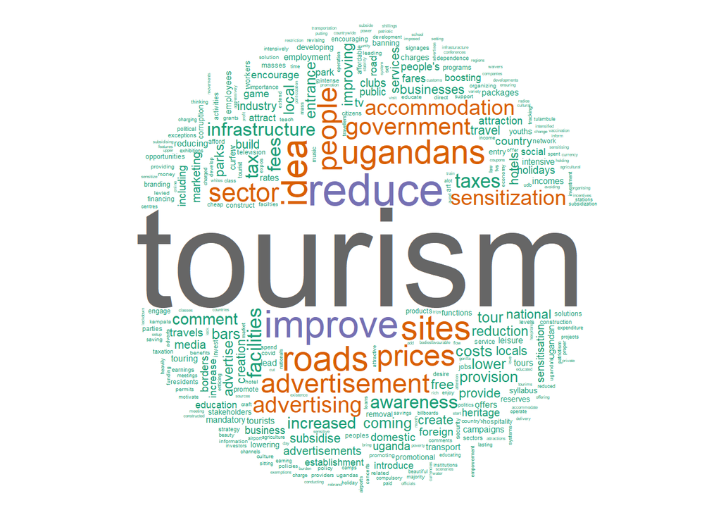

Table 42: Do you think there has been growth in Domestic Tourism over the last one year

| Response | count | percent(%) |
| --- | --- | --- |
| No | 892 | 84% |
| Yes | 174 | 16% |
| Total | 1066 | - |

Table 43: Barriers to growth in Domestic Tourism in 2020

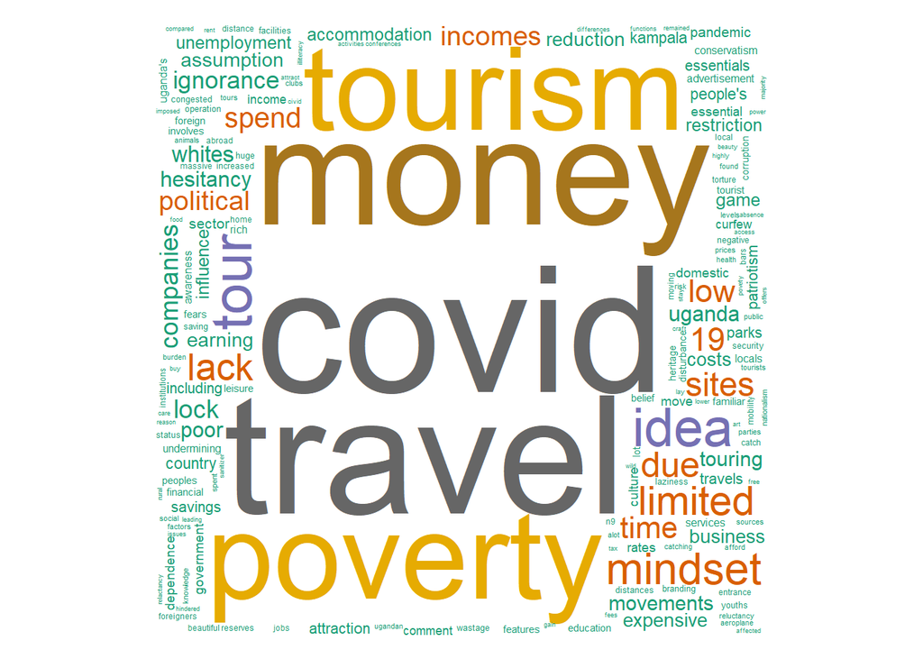

Table 44: Factors that have led to growth of Domestic Tourism in 2020:

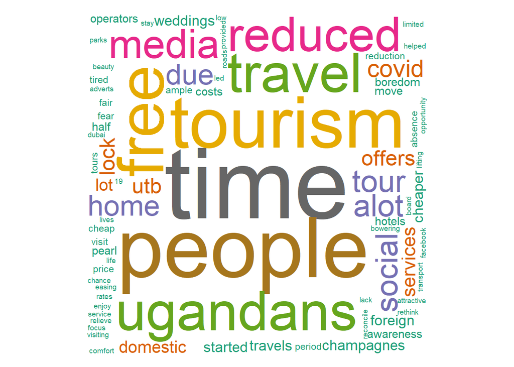

Back to top